# Comparing Datasets

# Introduction

## Problem

This script is designed to compare a collection of spreadsheets against a master (AKA ground-truth) spreadsheet. The objective is to determine if all rows in the collections of spreadsheets exist in the master, whilst also confirming that the master does not have extra rows that the collections are missing.

In a generalised sense, this problem can be visualised with the following diagrams.

1. Imagine the master spreadsheet is represented by a grey rectangle
2. Likewise, each of the other spreadsheets are represented by yellow, blue, and green rectangles

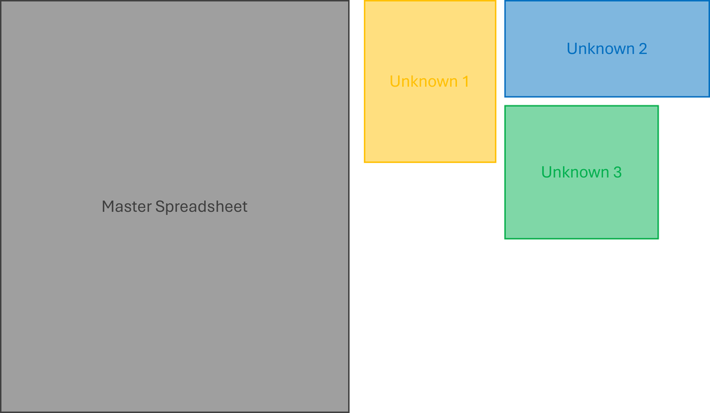

3. If all rows from the collection of spreadsheets (yellow, blue, green) exist in the master spreadsheet (grey), this can be visualised something like this:

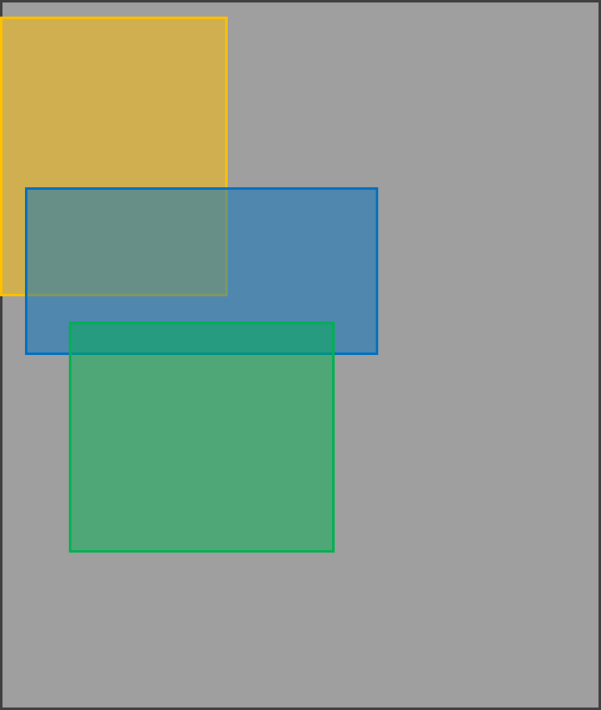

4. However if the collection of spreadsheets have columns that don’t exist in the master, it would look like this:

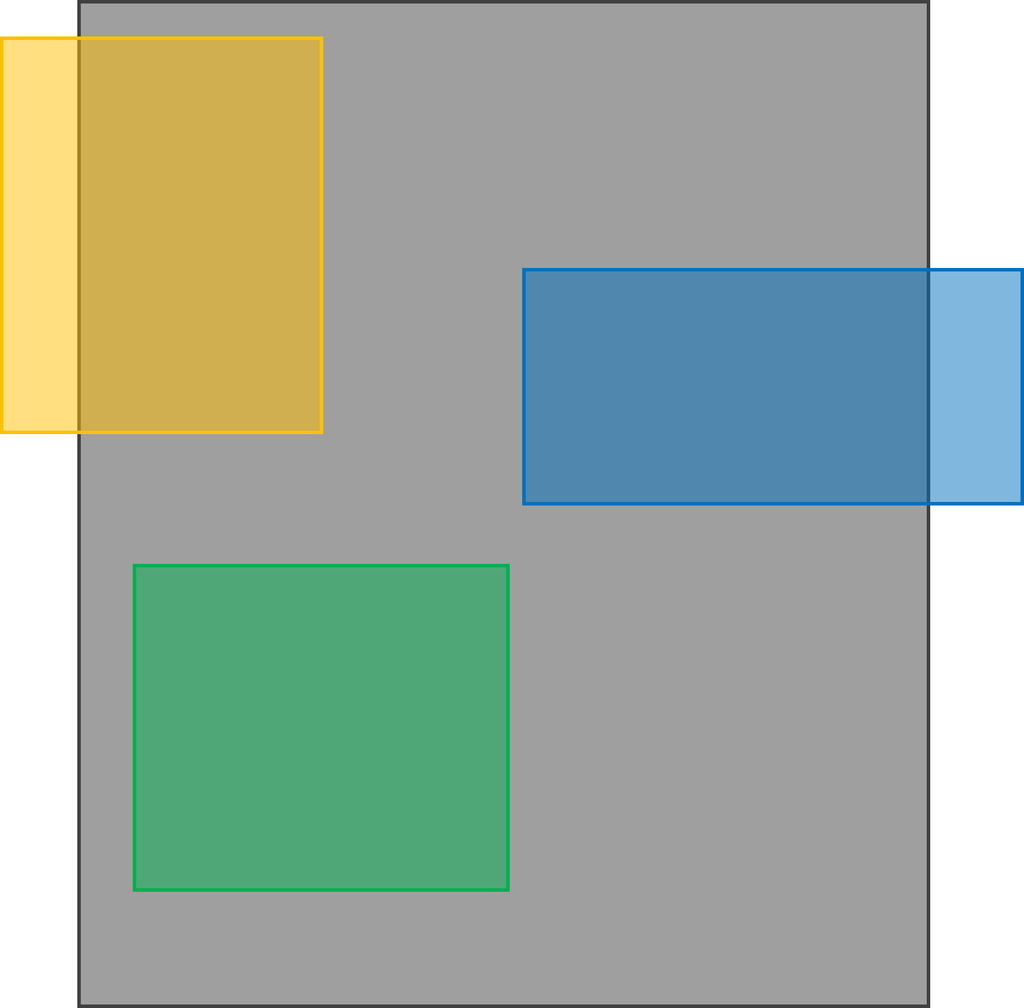

5. Likewise if the collection had rows that didn’t exist in the master it would look like this:

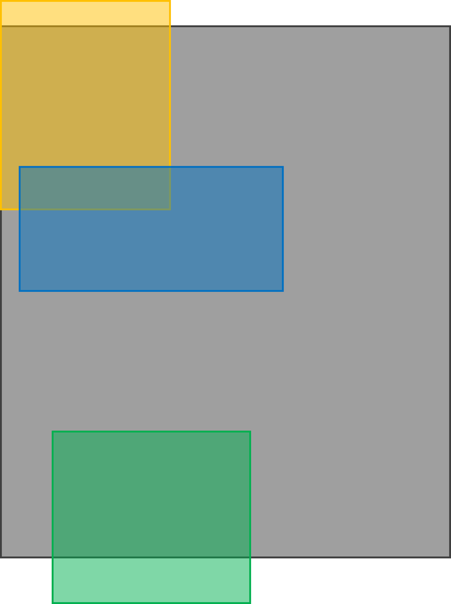

The task becomes determining where the collection of spreadsheets sit within the master spreadsheet, and identifying if the rows/columns actually do not exist in the master, or is there some small discrepency such as a typo that is causing the issue.

## Solution

There are several factors that may falsely cause discrepencies that must be consider when solving this issue, we must account for:

1. Alternative column names for the same data
2. Duplicate rows within the collection (e.g. due to overlapping dates)
3. Varied dataset scopes (e.g. a spreadsheet within the collection may only focus on DT, whilst another might focus on N3)
4. An extended mastersheet (i.e. the master sheet spans a greater length of time and will naturally have rows that don’t exist in the collection, likewise it spans a larger list of column variables than exists in the collection)

After accounting for these false positives, it is then possible to identify the source of any true positives (discrepencies) such as:

1. Missing rows
2. Missing columns
3. Cell errors

Finally, the solution must be as generic as possible so it can be applied in other scenarios.

# Set Up

Only a very simple set up is required, a few basic packages and then reading in all the data. Note that the collection of spreadsheets should be stored in a list, and the master should be kept separate.

```r
library(dplyr)
library(readxl)
library(purrr)
library(stringr)
library(ggplot2)
```

```r
#get a list of datasets
file_names <- list.files("data/", full.names = TRUE)

#load the master (ground-truth) data by itself
gt_data <- read_xlsx(file_names[4], sheet = 2)

#load the collection of datasets together
collection_data <- map(file_names[1:3], ~read_xlsx(.x, 2))
```

# Columns

The first step is to address differences in column names, to do this we will need to compile a list of all column names that exist across both the gt and collection datasets. The idea here is to determine the amount of “true” variation in column names. To make things easier to check, the column names should be ordered alphabetically.

```r
#extract all column names
all_col_names <- sort(
    unlist(
        map(
            c(list(gt_data), collection_data),
            colnames
        )
    )
)
```

```r
all_col_names
```

```
 [1] "ACOUSTIC_DEPTH"         "ACOUSTIC_DEPTH"         "ACOUSTIC_DEPTH"
 [4] "ATTRIBUTION"            "CHL (ug/L)"             "Chl_ug/L"
 [7] "Chl_ug/L"               "Chl_ug/L"               "COLLECTION_START_DATE"
[10] "DEPTH_AVG_TO"           "DIP (uM)"               "LATITUDE"
[13] "LATITUDE"               "LATITUDE"               "LATITUDE"
[16] "LOCATION_NAME"          "LOCATION_NAME"          "LOCATION_NAME"
[19] "LOCATION_NAME"          "LONGITUDE"              "LONGITUDE"
[22] "LONGITUDE"              "LONGITUDE"              "NH4 (uM)"
[25] "NH4_INSITU (uM)"        "NO2 (uM)"               "NO2_uM"
[28] "NO2_uM"                 "NO2_uM"                 "NO3 (uM)"
[31] "NO3_uM"                 "NO3_uM"                 "NO3_uM"
[34] "PN_SHIM (uM)"           "PN_uM"                  "PN_uM"
[37] "PN_uM"                  "PP (uM)"                "PP_uM"
[40] "PP_uM"                  "PP_uM"                  "PROJECT"
[43] "PROJECT"                "PROJECT"                "PROJECT"
[46] "SAMPLE_DATE"            "SAMPLE_DATE"            "SAMPLE_DATE"
[49] "SECCHI_DEPTH (m)"       "Secchi_depth_m"         "Secchi_depth_m"
[52] "Secchi_m"               "SHORT_NAME"             "SHORT_NAME"
[55] "SHORT_NAME"             "SHORT_NAME"             "SS (mg/L)"
[58] "STATION_CLASS"          "STATION_CLASS"          "STATION_CLASS"
[61] "STATION_CLASS"          "STATION_NAME"           "STATION_NAME"
[64] "STATION_NAME"           "STATION_NAME"           "TDN_PER (uM)"
[67] "TDN_SHIM (uM)"          "TDP_PER (uM)"           "TEMP (degrees Celsius)"
[70] "TSS_mg/L"               "TSS_mg/L"               "TSS_mg/L"
```

Looking at this list of names we can already spot some double ups, for instance “CHL (ug/L)” and “Chl_ug/L” refer to the same column and should have their name standardised. However, this is an area to tread cautiously - if you updated “XYZ (ug/L)” to match “XYZ_mg/L” you would be making a fatal error.

Generally it is a good idea to start with grammar and syntax, things like capitals, brackets, underscores, etc. Following this some obvious changes such as aligning “secchi depth m” and “secchi m” can occur. Finally, after some detailed exploration of the datasets we can indentify things such as “pn um” = “pn shim um”, “tss mg/l” = “ss mg/l” and “depth avg to” = “acoustic depth”.

```r
#create a list of replacements
replacements <- c(
    "collection start date" = "sample date",
    "secchi depth m" = "secchi m",
    "pn shim um" = "pn um",
    "^ss mg/l" = "tss mg/l",
    "depth avg to" = "acoustic depth"
)

all_col_names <- all_col_names |>
    str_to_lower() |>
    str_remove_all("\\(|\\)") |>
    str_replace_all("_", " ") |>
    str_replace_all(replacements) |>
    unique()

#generalise this method into a function for use later
col_name_cleaner <- function(input_string) {

    input_string |>
        as.character() |>
        str_to_lower() |>
        str_remove_all("\\(|\\)") |>
        str_replace_all("_", " ") |>
        str_replace_all(replacements)
}
```

This leaves us with a list of **all** possible unique column names across **all** of our datasets. Ideally we would then find that every single name in this list exists in the groundtruth spreadsheet. So lets check that out.

```r
#run function on gt data
gt_data <- gt_data |>
    rename_with(
        .cols = everything(),
        ~col_name_cleaner(.)
    )

#compare gt data column names to the list of all names
all(all_col_names %in% colnames(gt_data))
```

```
[1] TRUE
```

Sucess!

Conversely, the colnames that don’t exist in the collection are:

```r
collection_clean_data <- map(collection_data, ~rename_with(.x, ~col_name_cleaner(.)))

exists_2 <- all_col_names %in% colnames(collection_clean_data[[1]])

all_col_names[!exists_2]
```

```
[1] "attribution"          "dip um"               "nh4 um"
[4] "nh4 insitu um"        "tdn per um"           "tdn shim um"
[7] "tdp per um"           "temp degrees celsius"
```

On this side of things while more columns are missing, none are columns that we have historically used in the Technical Report. Therefore, for the purposes of this comparison these columns will be removed from the ground-truth dataset to basically arrive at the point where all columns are shared. Referencing the coloured rectangles again, note how the columns of the collection now exists fully within the master, and that the columns of the master have been cut down to match:

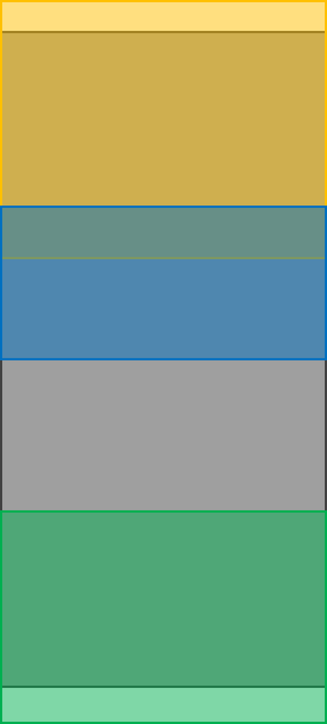

```r
gt_clean_data <- gt_data |>
    select(!all_col_names[!exists_2])
```

# Rows

Now that we have established that all differences in columns were false positives we can move on to inspecting rows.

First we will filter data by “short name” to only keep sites of interest (this vector can be updated as needed). This removes sites that are outside the N3 region and/or are not regularly monitored.

```r
short_names_to_keep <- c(
    "BUR1", "BUR10", "BUR13", "BUR2", "BUR4", "BUR7", "BUR8", #(burdekin/dry tropics sites)
    "C1", "C11", "C4", "C5", "C6", "C8", #(Wet Tropics)
    "RM1", "RM10", "RM11", "RM12", "RM2", "RM3", "RM4", "RM5", "RM6", "RM7", "RM8", "RM9", #(Wet Tropics)
    "TUL10", "TUL11", "TUL2", "TUL3", "TUL4", "TUL5", "TUL6", "TUL7", "TUL8", "TUL9", #(Wet Tropics)
    "WHI1", "WHI4", "WHI5", "WHI6", "WHI7" #(Whitsundays)
)

#apply to ground_truth
gt_clean_filtered_data <- gt_clean_data |>
    filter(`short name` %in% short_names_to_keep)

#apply to collection
collection_clean_filtered_data <- map(collection_clean_data, ~filter(.x, `short name` %in% short_names_to_keep))
```

Then we need to restrict our timeframes, looking at the min date from the collection is a reasonable cutoff point, but to ensure we don’t make any mistakes if the collection has been accidently cut off early we will move the cutoff to the start of the year rather than mid year (i.e. instead of 2020-07-09 we will use 2020-01-01).

```r
gt_clean_filtered_data <- gt_clean_filtered_data |>
    filter(`sample date` >= "2020-01-01")

collection_clean_filtered_data <- map(collection_clean_filtered_data, ~filter(.x, `sample date` >= "2020-01-01"))
```

This leaves us with the following stats:

```r
gt_min <- min(gt_clean_filtered_data$`sample date`)
gt_max <- max(gt_clean_filtered_data$`sample date`)
gt_length <- length(unique(gt_clean_filtered_data$`sample date`))

collect_min <- min(do.call("c", map(collection_clean_filtered_data, ~min(.x$`sample date`))))
collect_max <- max(do.call("c", map(collection_clean_filtered_data, ~max(.x$`sample date`))))
collect_length <- length(unique(unlist(map(collection_clean_filtered_data, ~unique(.x$`sample date`)))))
```

- GT min: 2020-01-06 07:05:00
- GT max: 2025-06-23 12:36:00
- GT count: 1213
- GT range: 1995.22986111111
- Collection min: 2020-07-09
- Collection max: 2024-06-10 15:12:00
- Collection count: 452
- Collection range: 1432.63333333333

As we would expect the GT table has both an earlier start and later finish, however the total count of unique dates is still way higher than is expected. To demonstate this, consider the following sampling rates:

```r
gt_range <- as.numeric(gt_max - gt_min)
collect_range <- as.numeric(collect_max - collect_min)

gt_sample_rate <- gt_range/gt_length
collect_sample_rate <- collect_range/collect_length
```

- GT sample rate: 1.6448721
- Collection sample rate: 3.1695428

This is basically saying the GT table has twice as many samples within the same timeframe as the collection of spreadsheets. I.e., with the timeframe established by the collection there are missing rows. This can be explained with the following plot which highlights a series of missing values for the 2022 period:

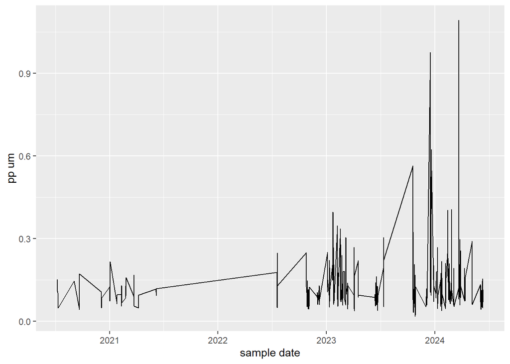

```r
ggplot(do.call(bind_rows, collection_clean_filtered_data), aes(x = `sample date`, y = `pp um`)) +
    geom_line()
```

This is simply the case because we don’t appear to have an original record of the 2022 data on file.

(Note, once the 2022 data is found this section is not necessary).